# Introduction to R, Polynomial Evaluation, and Programming Practice

### Objectives

- R and R Markdown introduction
- Understand vectors, matrices, and functions in R
- Review basic programming skills (functions, for loops, if-then statements)

### Part I: Vectors and Matrices in R

Here are a few different ways to create vectors in R:

```r
v=c(2,3,6) # this is a column vector
print(v) # just so you can see what we created
```

```
## [1] 2 3 6
```

```r
v # here is another way to see what we created
```

```
## [1] 2 3 6
```

```r
(v=c(2,3,6)) #putting parentheses around a command will also display the output
```

```
## [1] 2 3 6
```

```r
w=2:5
print(w)
```

```
## [1] 2 3 4 5
```

```r
y=seq(0, 10, 2) #The syntax of this is seq(from, to, by=)
print(y)
```

```
## [1]  0  2  4  6  8 10
```

There are also a few different ways to generate matrices in R. One is to use the commands `rbind` or `cbind` to bind together multiple row and column vectors. Here are some examples:

```r
(G=cbind(c(1,4,7),c(2,5,8),c(3,6,9))) # note that if you put parentheses around the entire line, the result is printed
```

```
##      [,1] [,2] [,3]
## [1,]    1    2    3
## [2,]    4    5    6
## [3,]    7    8    9
```

```r
(H=rbind(c(1,2,3),c(4,5,6),c(7,8,9)))
```

```
##      [,1] [,2] [,3]
## [1,]    1    2    3
## [2,]    4    5    6
## [3,]    7    8    9
```

This works fine for small matrices but is not ideal if we have larger matrices with nice structured entries. Here is a way to create a matrix filled with entries of the same value:

```r
(Z = matrix(0, nrow = 10, ncol = 10))
```

```
##       [,1] [,2] [,3] [,4] [,5] [,6] [,7] [,8] [,9] [,10]
##  [1,]    0    0    0    0    0    0    0    0    0     0
##  [2,]    0    0    0    0    0    0    0    0    0     0
##  [3,]    0    0    0    0    0    0    0    0    0     0
##  [4,]    0    0    0    0    0    0    0    0    0     0
##  [5,]    0    0    0    0    0    0    0    0    0     0
##  [6,]    0    0    0    0    0    0    0    0    0     0
##  [7,]    0    0    0    0    0    0    0    0    0     0
##  [8,]    0    0    0    0    0    0    0    0    0     0
##  [9,]    0    0    0    0    0    0    0    0    0     0
## [10,]    0    0    0    0    0    0    0    0    0     0
```

You can also generate matrices as the products of vectors. Here is an example:

```r
v1=c(-1,0,2)
v2=c(0,1,1)
M=v1%*%t(v2) #Notice the t transposes the vector.
print(M)
```

```
##      [,1] [,2] [,3]
## [1,]    0   -1   -1
## [2,]    0    0    0
## [3,]    0    2    2
```

What are the dimensions of the vectors in the above example? **Note that matrix-vector or vector-vector multiplication requires the percentage symbols around the asterisk.** What happens if you leave them out? Try it!

We’ll talk about other ways to create matrices (particularly sparse matrices with many zero entries) as the semester progresses.

Once you have a matrix, you can change specific entries with square brackets after the matrix. Here are some examples:

```r
G[2,2]=22
print(G)
```

```
##      [,1] [,2] [,3]
## [1,]    1    2    3
## [2,]    4   22    6
## [3,]    7    8    9
```

```r
H[2,]=c(-4,-5,-6)
print(H)
```

```
##      [,1] [,2] [,3]
## [1,]    1    2    3
## [2,]   -4   -5   -6
## [3,]    7    8    9
```

To create a for loop in R, follow the syntax below:

```r
y=rep(0,10) #This repeats the element 0 ten times
for (i in 1:10){
  y[i]=i
}
print(y)
```

```
##  [1]  1  2  3  4  5  6  7  8  9 10
```

This is a silly way to create a vector, which can be done in only one line with the commands above.

1. Now it’s your turn. Generate the following matrices. You can try it with `for` loops, but you should also be able to do it with just a line or two of shorter code.

$$\begin{bmatrix}
1 & 1 & 1 & 1 & 1 & 1 & 1 \\
1 & 1 & 1 & 1 & 1 & 1 & 1 \\
1 & 1 & 1 & 1 & 1 & 1 & 1 \\
1 & 1 & 1 & 1 & 1 & 1 & 1 \\
1 & 1 & 1 & 1 & 1 & 1 & 1 \\
1 & 1 & 1 & 5 & 5 & 5 & 1 \\
1 & 1 & 1 & 5 & 5 & 5 & 1 \\
1 & 1 & 1 & 1 & 1 & 1 & 1
\end{bmatrix}$$

```r
(Z = matrix(1, nrow = 8, ncol = 7))
```

```
##      [,1] [,2] [,3] [,4] [,5] [,6] [,7]
## [1,]    1    1    1    1    1    1    1
## [2,]    1    1    1    1    1    1    1
## [3,]    1    1    1    1    1    1    1
## [4,]    1    1    1    1    1    1    1
## [5,]    1    1    1    1    1    1    1
## [6,]    1    1    1    1    1    1    1
## [7,]    1    1    1    1    1    1    1
## [8,]    1    1    1    1    1    1    1
```

```r
Z[6:7, 4:6] = 5
Z
```

```
##      [,1] [,2] [,3] [,4] [,5] [,6] [,7]
## [1,]    1    1    1    1    1    1    1
## [2,]    1    1    1    1    1    1    1
## [3,]    1    1    1    1    1    1    1
## [4,]    1    1    1    1    1    1    1
## [5,]    1    1    1    1    1    1    1
## [6,]    1    1    1    5    5    5    1
## [7,]    1    1    1    5    5    5    1
## [8,]    1    1    1    1    1    1    1
```

```r
b1 = c(1, 2, 3, 4, 5, 6, 7, 8) #Column Vector
b2 = c(1, 2, 3, 4, 5, 6, 7, 8, 9, 10) #Row Vector(After Transpose)
MB = b1%*%t(b2) #Creates above Matrix, t(b2) = transpose b2 to Row Vec
print(MB)   #C1 interpreted as a column vector
```

[output not shown]

```
##      [,1] [,2] [,3] [,4] [,5] [,6] [,7] [,8] [,9] [,10]
## [1,]    1    2    3    4    5    6    7    8    9    10
## [2,]    2    4    6    8   10   12   14   16   18    20
## [3,]    3    6    9   12   15   18   21   24   27    30
## [4,]    4    8   12   16   20   24   28   32   36    40
## [5,]    5   10   15   20   25   30   35   40   45    50
## [6,]    6   12   18   24   30   36   42   48   54    60
## [7,]    7   14   21   28   35   42   49   56   63    70
## [8,]    8   16   24   32   40   48   56   64   72    80
```

$$\begin{bmatrix}
1 & 1 & 1 & 1 & 1 \\
4 & 4 & 4 & 4 & 4 \\
9 & 9 & 9 & 9 & 9 \\
\vdots & \vdots & \vdots & \vdots & \vdots \\
121 & 121 & 121 & 121 & 121
\end{bmatrix}$$

```r
c3 = (1:11)^2 #Vector of first 11 squares
c1 = c(1, 4, 9, 16, 25, 36, 49, 64, 81, 100, 121)
c2 = c(1, 1, 1, 1, 1) #Vecor of ones
MC = c1%*%t(c2) #Outer product taken with transpose
print(MC)
```

```
##       [,1] [,2] [,3] [,4] [,5]
##  [1,]    1    1    1    1    1
##  [2,]    4    4    4    4    4
##  [3,]    9    9    9    9    9
##  [4,]   16   16   16   16   16
##  [5,]   25   25   25   25   25
##  [6,]   36   36   36   36   36
##  [7,]   49   49   49   49   49
##  [8,]   64   64   64   64   64
##  [9,]   81   81   81   81   81
## [10,]  100  100  100  100  100
## [11,]  121  121  121  121  121
```

### Part II: Functions and Polynomial Evaluation

Here is an example of how to create a function in R:

```r
my.line=function(x){
  y=2*x-3
  return(y)
}
```

I can evaluate the function at a specific value of $x$:

```r
my.line(2)
```

```
## [1] 1
```

or at multiple values of $x$:

```r
xx=3:7
my.line(xx)
```

```
## [1]  3  5  7  9 11
```

You can also write a function that creates a function and returns the function handle. Here is an example:

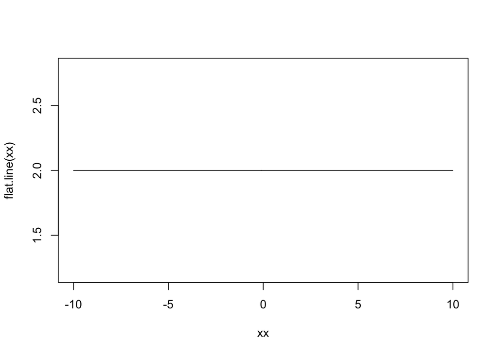

```r
generate.line.fn=function(slope,intercept){
  my.line.fn=function(x){
    y=slope*x+intercept
    return(y)
  }
  return(my.line.fn)
}
flat.line=generate.line.fn(0,2)
xx=seq(-10,10,by=.1)
plot(xx,flat.line(xx),type="l")
```

2. Discuss with each other what each line in the above code is doing. Make sure you understand the idea of a function that returns a handle to another function.
3. Implement Horner’s method in R. It should be of the form `Horner(coeffs,x)` and it should return the value of the polynomial whose coefficients are given by the vector `coeffs`, evaluated at the scalar $x$. Make sure to include comments describing what your function is doing, and also test your function with sample inputs.

```r
Horner = function(coeffs, x) {
  total = 0
  for(i in 0:length(coeffs)){
    if(i<length(coeffs)){
      if(i > 1) {
        total = x * total + coeffs[i+1]
      } else {
        total = x * coeffs[i] + coeffs[i+1]
      }
    }
  }
  return(total)
}

coeffV = 1:3
coeff2 = 4:6
coeff3 = c(4, 5, 6)
Horner(coeffV, 1)
```

```
## [1] 6
```

```r
Horner(coeff2, 1)
```

```
## [1] 15
```

```r
Horner(coeff3, 1)
```

```
## [1] 15
```

4. Now implement the naive method, the unnested version of polynomial evaluation. Make sure to include comments describing what your function is doing, and also test your function with sample inputs. Which is faster? To check the time spent computing, you can use the R command: `print(system.time( #insert_code_here ) )`

```r
naive=function(coeffs, x){
  total = 0
  for(i in 1:length(coeffs)){
    if(i>1){
      temp = x^(i-1) * coeffs[i]
      total = total + temp
    } else {
      total = total + coeffs[i]
    }
  }
  return(total)
}

coeffV = 1:3
naive(coeffV, 1)
```

```
## [1] 6
```

```r
coeff2 = 4:6
naive(coeff2, 1)
```

```
## [1] 15
```

```r
coeffT=1:10000
coeffTT=1:100000

print(system.time(naive(coeffT, 1) ) )
```

```
##    user  system elapsed
##   0.002   0.000   0.002
```

```r
print(system.time(naive(coeffTT, 1) ) )
```

```
##    user  system elapsed
##   0.016   0.000   0.017
```

```r
print(system.time(Horner(coeffT, 1) ) )
```

```
##    user  system elapsed
##   0.003   0.000   0.003
```

```r
print(system.time(Horner(coeffTT, 1) ) )
```

```
##    user  system elapsed
##   0.031   0.001   0.033
```

5. Make a vectorized version that evaluates a polynomial whose coefficients are given by the vector `coeffs` at the scalar $x$, **without any for loops**.

```r
Vectorized = function(coeffs, x) {
  y = coeffs %*% x^(0:(length(coeffs)-1))
  return(y)
}
coeffV = 1:3
Vectorized(coeffV, 1)
```

```
##      [,1]
## [1,]    6
```

### Part III: The Office Space Problem

If you’ve finished the above exercises, you can start with the following problem, which will be the first problem on HW1.

The point of this problem is twofold: (i) to illustrate what can happen if you accumulate many truncations of numbers and (ii) to give you practice writing programs.

In the 1999 movie Office Space, a character creates a program that takes fractions of cents that are truncated in a bank’s transactions and deposits them into his own account. This is not a new idea, and hackers who have actually attempted it have been arrested. In this exercise, you will simulate the program to determine how long it would take to become a millionaire this way.

Assume the following details:

- You have access to 10,000 bank accounts
- Initially, the bank accounts have values that are uniformly distributed between $100 and $100,000
- The annual interest rate on the accounts is 5%
- Interest is compounded each day and added to the accounts, except that fractions of a cent are truncated
- The daily interest rate is thus .05/365
- The truncated fractions are deposited into an illegal account that initially has a balance of $0
- The illegal account can hold fractional values and it also accrues daily interest

Your job is to write R code that simulates this situation and finds how long it takes for the illegal account to reach a million dollars.